# Overview of Statistical Learning and Modeling – 36-600

Lab 2T: Confidence Intervals Due Wednesday, September 3, 11:59pm

Trishla Nair

We start by describing the functions that `R` provides that relate to probability distributions. We’ll start by giving the name of one of these: `dnorm()`. (You may have noticed that I tack on parentheses after function names. This is to make it clear to the reader that what is being referred to is a function and not, say, a variable.) We can split the name into two parts:

- `d`: this means that the function is returning $f_X(x)$, i.e., the probability density function value given the coordinate $x$; and
- `norm`: this means that we are working with the normal distribution.

First we’ll list the names of some common distributions:

| `R` Name | Distribution | Parameters (See Help Pages For More) |
| --- | --- | --- |
| `binom` | Binomial | `size` ($n$) and `prob` ($p$) |
| `pois` | Poisson | `lambda` ($\lambda$) |
| `norm` | Gaussian (/Normal) | `mean` ($\mu$) and `sd` ($\sigma$) |
| `t` | t | `df` ($\nu$) |
| `exp` | Exponential | `rate` ($\beta$) |
| `chisq` | Chi-square(d) | `df` ($\nu$) |

And second we’ll list the prefixes that you use to accomplish various tasks:

| Prefix | What it Does |
| --- | --- |
| `d` | returns the p.d.f. $f_X(x)$ or p.m.f. $p_X(x)$ |
| `p` | returns the c.d.f. $F_X(x)$ |
| `q` | returns the inverse c.d.f. $F_X^{-1}(x)$ |
| `r` | returns a random sample of data |

What’s the c.d.f.? It’s the *cumulative distribution function*, and we defined it in the notes as the probability that we sample a datum $\leq x$, where $x$ is the coordinate that we input into the c.d.f. For instance,

```r
pbinom(5, size = 10, prob = 0.5)
```

```
## [1] 0.6230469
```

is the probability that we would observe 0, 1, 2, 3, 4, *or* 5 heads when flipping a fair coin 10 times, and

```r
pnorm(60, mean = 75, sd = 10)
```

```
## [1] 0.0668072
```

is the probability of scoring 60 or less on a test whose true average score is 75, with standard deviation 10, *if* the test scores are truly normally distributed.

(The inverse c.d.f. is, well, the inverse function: given a probability between 0 and 1, what is the associated $x$ coordinate? For instance,

```r
qnorm(0.6, mean = 75, sd = 10)
```

```
## [1] 77.53347
```

tells us that on average, 60% of students will have a test score $\leq 77.53$.)

Before we play, we need to point out one more thing. Recall that you can define a vector using the `seq()` function. For instance,

```
seq(0, 10, by = 0.1)
```

defines the sequence {0, 0.1, 0.2, …, 9.9, 10}. As we’ll see, if we want to plot distributions, defining a sequence is a good way to start.

## Question 1

Define an appropriate vector `x` and plot the probability density function $f_X(x)$ on the y-axis versus $x$ on the x-axis for a normal distribution with mean 5 and standard deviation 2. To give you a hint as to how “wide” to define the sequence of values `x`, know that in general, nearly all the probability content of a distribution lies within three standard deviations of the mean. Put a little cushion on this, and define the sequence to stretch over a range of four or five standard deviations on either side of the mean. And for the plotting bit, you can create a basic plot via `plot(x, y, type = "l")`. (Eventually we’ll move to `ggplot()` for some higher-quality plotting, but let’s start here.)

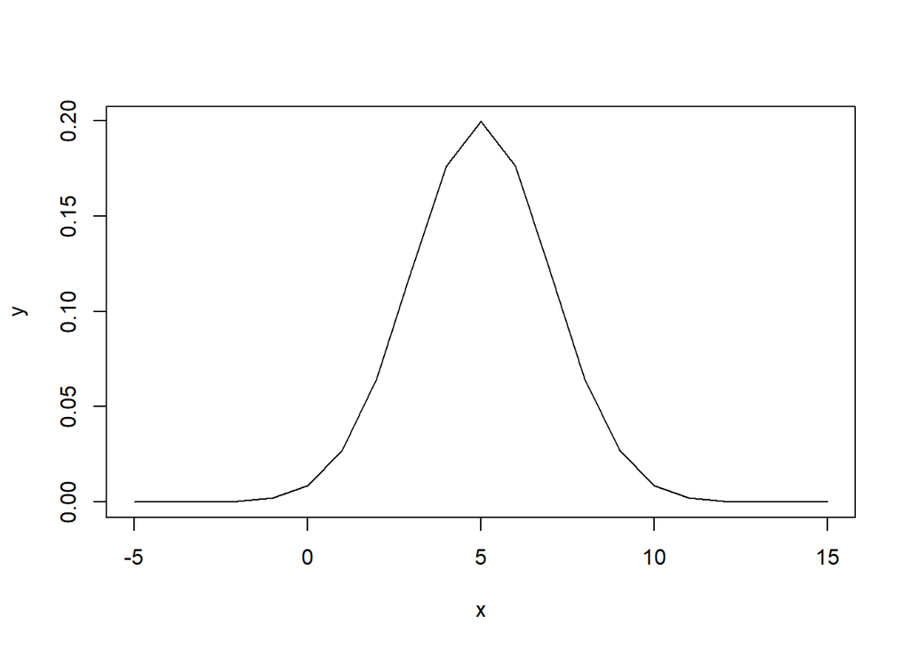

```r
x<-seq(-5, 15)
y <-dnorm(x, mean = 5, sd = 2)
plot(x, y, type = "l")
```

## Question 2

Compute the probability that, given the distribution from Question 1, we would sample a datum that has a value greater than 4. (Recall the definition of the c.d.f., and make a necessary adjustment.)

```r
pnorm(4, mean = 5, sd = 2)
```

```
## [1] 0.3085375
```

## Question 3

Sample 100 data from the distribution defined in Question 1. Use `sum()` and a relational operator to display how many of the data are less than 5. Then incorporate `length()` to display the *proportion* of the data that are less than 5. Note that this proportion is a random variable: you will not get the same result as your neighbor, unless dumb luck intervenes, or…see Question 4.

```r
sample <- rnorm(100, 5, 2)
length(sample[sample<5])
```

```
## [1] 64
```

## Question 4

What you will find is that each time you run the code in the code chunk for Question 3, you will get a different result. The reason is that every time you sample, you get a different dataset. This affects reproducibility. Hence, when you sample data, you should always set a *random number seed* first. You do that in `R` by calling the function `set.seed()` and passing in a number (your choice) as an argument.

Below, set the random number seed, sample five numbers from the distribution defined in Question 1, and display your sample. (You can do this by simply saying `x`, or by saying `print(x)`.) Then repeat the process with the same random number seed. You should see that your five numbers are exactly the same.

```r
set.seed(42)
sample <- rnorm(5, 5, 2)
sample
```

```
## [1] 7.741917 3.870604 5.726257 6.265725 5.808537
```

## Question 5

Plot the probability mass function $p_X(x)$ for a binomial distribution with $n = 20$ and $p = 0.5$. (Here, instead of using the `plot()` argument `type = "l"`, use `pch = 19`.) Does it look like a normal distribution, at least in general shape? Next, make two more p.m.f. plots, one with $p = 0.1$ and one with $p = 0.9$. Do these p.m.f.s have a similar shape to a normal distribution? For the `x` in your plot, use `x <- 0:20`, i.e., `x` has values 0, 1, …, 20.

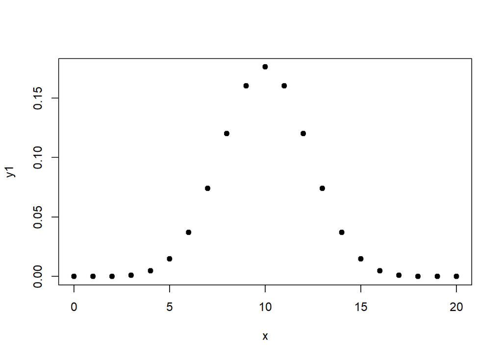

```r
x<- 0:20
y1 <-dbinom(x, size = 20, prob = 0.5)
y2 <-dbinom(x, size = 20, prob = 0.1)
y3 <-dbinom(x, size = 20, prob = 0.9)
plot(x, y1, pch = 19)
```

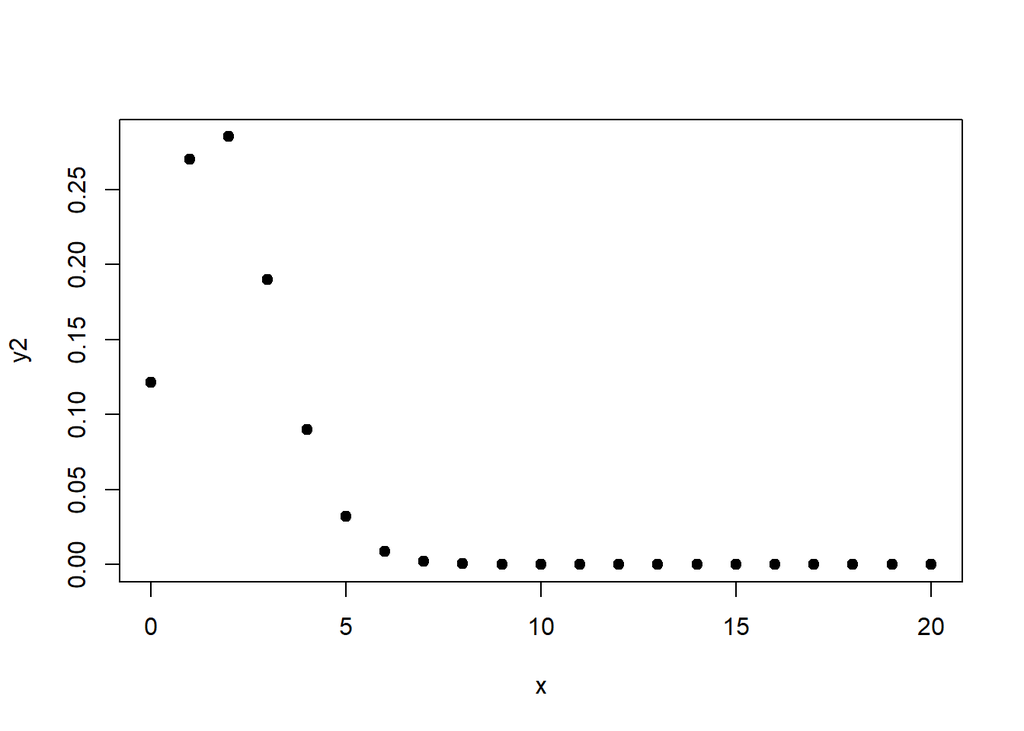

```r
plot(x, y2, pch = 19)
```

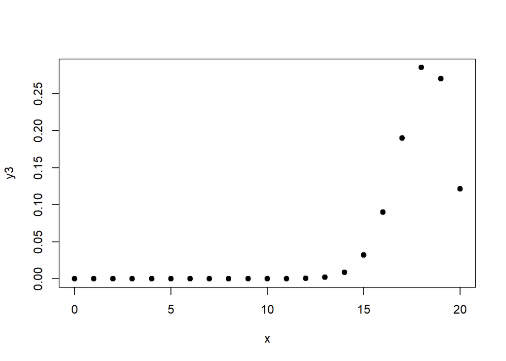

```r
plot(x, y3, pch = 19)
```

## Question 6

Plot the probability mass function $p_X(x)$ for a Poisson distribution with $\lambda = 2$ and $\lambda = 10$. (Use the `plot()` argument `pch = 19` again.) You should see that as $\lambda$ gets larger, the Poisson p.m.f. adopts a shape more and more like that of a normal distribution. Here, use the same `x` as above (0:20).

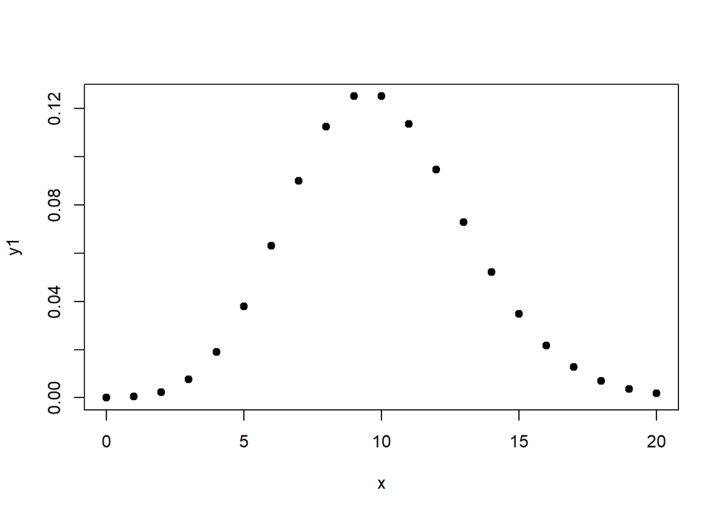

```r
x<- 0:20
y1 <-dpois(x, lambda= 2)
y1 <-dpois(x, lambda= 10)
plot(x, y1, pch = 19)
```

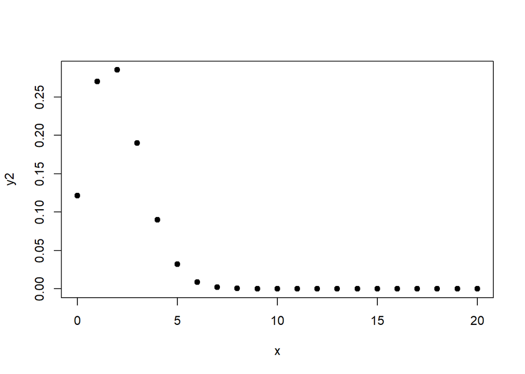

```r
plot(x, y2, pch = 19)
```

## Question 7

Generate a vector with $n = 100$ data from a normal distribution with mean 10 and standard deviation 2. (Remember to set a seed first!)

Statisticians generally do not like working with entire datasets, when it is possible to make inferences with *summary statistics*. These statistics include ones like the *sample mean*, the *sample standard deviation*, the *sample median*, etc. Below, compute these statistics, via the `mean()`, `sd()`, and `median()` functions. Also, pass your vector to the `summary()` function, which gives a six-number summary showing the minimum value (which you can also find with the function `min()`), the maximum value (`max()`), the mean and median, and the 25th and 75th percentiles.

```r
set.seed(42)
sample <- rnorm(100, 10, 2)
print(mean(sample))
```

```
## [1] 10.06503
```

```r
print(sd(sample))
```

```
## [1] 2.082714
```

```r
print(median(sample))
```

```
## [1] 10.17959
```

```r
print(summary(sample))
```

```
##    Min. 1st Qu.  Median    Mean 3rd Qu.    Max.
##   4.014   8.767  10.180  10.065  11.323  14.573
```

## Question 8

Construct a 95% two-sided confidence interval for the mean of the distribution that you just sampled data from in the previous question. (Forget that you know the mean is 10.) To do this, use the pseudo-code from the notes:

```
f <- function(theta, [arguments]) {
  [cumulative distribution function]([arguments]) - q
}
uniroot(f, interval = [interval], [arguments], q = 1-alpha/2)$root
uniroot(f, interval = [interval], [arguments], q = alpha/2)$root
```

Here, the `theta` is $\mu$, or `mu`, the mean of a normal distribution. A few more details:

1. We will assume that the standard deviation is *known* and is equal to 2. That means that the sample mean $\overline{X}$ is normally distributed (i.e., use `pnorm()`) with mean $\mu$ (i.e., use `mean = mu` as one argument) and standard deviation $2/\sqrt{n} = 0.2$ (i.e., use `sd = 0.2` as the other argument).
2. The range of possible values for $\mu$ is technically infinite, so use a wide range for `interval` that includes negative and positive values (e.g., `interval = c(-100, 100)`).
3. The additional arguments to `f()` are any variables that you would need to get the cumulative distribution function to run. Since we hard-coded `sd = 0.2`, we don’t need $\sigma$ or $n$…but we do need `q`, and we need the observed value of $\overline{X}$!
4. Our confidence coefficient is 0.95, so $\alpha = 0.05$.

If you run into issues, call me or a TA over!

```r
alpha <- 0.05
set.seed(42)
sample <- rnorm(100, 10, 2)

f <- function(mu, x.bar, s, n, q) {
  pt((x.bar - mu) / (s / sqrt(n)), n - 1) - q}

uniroot(f, interval = c(-100, 100), x.bar = mean(x), s = 0.2, n = length(sample), q = 1-alpha/2)$root
```

```
## [1] 9.960289
```

```r
uniroot(f, interval = c(-100, 100), x.bar = mean(x), s = 0.2, n = length(sample), q = alpha/2)$root
```

```
## [1] 10.0397
```

## Question 9

Confirm your result in Question 8 using the `R` function `z.test()`.

Well, this would be the appropriate function to test a statistic of this form, under these assumptions, except…there is no `R` function called `z.test()`, at least not in the base-`R` distribution. To run a $z$-test, first type `install.packages("BSDA")` in the Console pane. Then uncomment `#library(BSDA)` in the code chunk below, and code and run `z.test()` (while noting that one of the arguments is `sigma.x=2`). The confidence interval will be output under the line `95 percent confidence interval:`. You can ignore any other output.

```r
library(BSDA)
set.seed(42)
sample <- rnorm(100, 10, 2)
z.test(x = sample, mu = mean(sample), sigma.x =2, conf.level = 0.95)
```

```
##
##  One-sample z-Test
##
## data:  sample
## z = 0, p-value = 1
## alternative hypothesis: true mean is not equal to 10.06503
## 95 percent confidence interval:
##   9.673037 10.457022
## sample estimates:
## mean of x
##  10.06503
```

## Question 10

Sometimes we don’t want to construct a two-sided interval…sometimes we just want a lower or upper bound on the parameter of interest $\theta$. Let’s suppose that now, we wish to place a 95% one-sided upper bound on $\mu$ for a normal distribution, given our current dataset.

What would we do differently here, compared to what we did in Question 8? Not much, actually. All we need to do is eliminate the first call to `uniroot()` and change `q = alpha/2` in the second call to `q = alpha`. Do this here, and find the upper bound. Confirm your result by calling `z.test()` with `sigma.x = 2` and `alternative = "less"`.

```r
alpha <- 0.05
set.seed(42)
sample <- rnorm(100, 10, 2)

f <- function(mu, x.bar, s, n, q) {
  pt((x.bar - mu) / (s / sqrt(n)), n - 1) - q}
uniroot(f, interval = c(-100, 100), x.bar = mean(x), s = 0.2, n = length(sample), q = alpha)$root
```

```
## [1] 10.0332
```

```r
set.seed(42)
sample <- rnorm(100, 10, 2)
z.test(x = sample, mu = mean(sample), sigma.x =2, conf.level = 0.95, alternative = "less")
```

```
##
##  One-sample z-Test
##
## data:  sample
## z = 0, p-value = 0.5
## alternative hypothesis: true mean is less than 10.06503
## 95 percent confidence interval:
##      NA 10.394
## sample estimates:
## mean of x
##  10.06503
```

## Question 11

Over the last ten years, you have observed this many eruptions from a particular volcano:

```
0 2 1 0 1 2 0 0 1 1
```

You assume the data are Poisson distributed. What is a 95% two-sided confidence interval for the mean of this distribution? (That mean is conventionally denoted $\lambda$, or `lambda`.)

We said we’d provide the details on sampling distributions. We did not lie.

1. The statistic that you would use is the *sum* of the data (which has value 8).
2. The sampling distribution for this statistic is a Poisson distribution with mean $10 \lambda$.

So how would you change your code in Question 8? Some hints for forming your interval:

1. For a Poisson distribution: use `ppois()`.
2. The arguments to `ppois()` are the sum (call this `x.sum`) and the parameter value (call this `lambda = nlambda`). Change `mu` in the call to `f()` with `nlambda`.
3. `nlambda` cannot be negative, so use, e.g., `interval = c(0, 100)`.
4. At the end of each call to `uniroot()`, tack on `/10` so that we get an interval for $\lambda$ rather than an interval for $10 \ lambda$.

```r
x <- c(0, 2, 1, 0, 1, 2, 0, 0, 1, 1)
alpha <- 0.05
x.sum <- 8
nlambda<- 10

f <- function(nlambda, x.sum, q) {
  ppois(x.sum, lambda = nlambda)-q}

uniroot(f, interval = c(0, 100),x.sum = x.sum, q = 1-alpha/2)$root/10
```

```
## [1] 0.4115391
```

```r
uniroot(f, interval = c(0, 100),x.sum=x.sum,q = alpha/2)$root/10
```

```
## [1] 1.576319
```

## Question 12

Sample 100,000 data from the vector 1:100000, with replacement, and count up the number of unique values that you observe (and divide this sum by 100000). This will provide you with the approximate probability that in any one bootstrapped dataset you will observe a given row from your original dataset one or more times. (The answer you should find is about 0.63.)

```r
vec <- 1:100000
s<-sample(vec, replace = TRUE)
print(length(unique(s))/100000)
```

```
## [1] 0.63141
```

## Question 13

In the notes, we computed a bootstrap confidence interval for the population mean $\mu$ using the sample mean $\overline{X}$ as our statistic. What happens if we use the sample median instead? (The relevant `R` function is `median()`.) Is the new bootstrap confidence interval wider? (Wider would mean that when we use this statistic, we would be more uncertain about the mean!) Recall that the interval found in the notes is $[4.527,5.268]$. Note that all you need to do here is copy the code from the notes and switch out the mean for the median.

```r
set.seed(101)
k     <- 10000
x.bar <- rep(NA, k)
for (ii in 1:k) {
  s         <- sample(length(x), length(x), replace = TRUE)
  x.bar[ii] <- median(x[s])
}
quantile(x.bar, probs = c(0.025, 0.975))
```

```
##  2.5% 97.5%
##   0.0   1.5
```